# hystreet

Der Dienst “Hystreet” zeichnet in rund 60 Städten in Deutschland mit einer Art Lichtschranke auf, wie viele Menschen sich in Fußgängerzonen aufhalten.

Wir zeigen hier den Einfluss der "social distancing"-Maßnahmen auf den Passantenverkehr in Fußgängerzonen.

Dazu vergleichen wir den Zeitraum 1.1.2020 - 30.3.2020 mit dem entsprechenden Vorjahreszeitraum, wobei der Vorjahreszeitraum um 1 Tag verrückt wurde, um Wochentags vs. Wochenends-Effekte zu berücksichtigen (Beispiel: Es wird nicht 1.3.2020 mit 1.3.2019 verglichen, sondern Sonntag, 1.3.2020 mit Sonntag, 3.3. (ja, genau, Schaltjahr 2020)

**Datenauswahl**

Einige Stationen messen nicht jeden Tag oder messen `0`.

**Notebooks**

- Datenauswahl: `process--1-filter-hystreet-for-valid-data.ipynb`
- Datums-shift: `process--2-make-2019-2020-comparable-for-fahrrad-and-hystreet.ipynb`

```python
%matplotlib inline
import pandas as pd
from matplotlib import pyplot as plt

from runpandarun.datasets import hystreet
```

```python
# setup style
FIGSIZE = (10, 5)
plt.style.use('ggplot')
```

```python
df = hystreet['compare_2019_2020']
df.head()
```

| week | weekday | pedestrians_count_2019 | weather_condition_2019 | temperature_2019 | min_temperature_2019 | station_id | year_2019 | date_2019 | pedestrians_count_2020 | weather_condition_2020 | temperature_2020 | min_temperature_2020 | year_2020 | date_2020 | name | city |
| --- | --- | --- | --- | --- | --- | --- | --- | --- | --- | --- | --- | --- | --- | --- | --- | --- |
| 1 | 3 | 17716 | partly-cloudy-day | 3.03 | -4.44 | 93 | 2019 | 2019-01-03 | 18709 | clear-day | 3.20 | -2.00 | 2020 | 2020-01-02 | Große Bleichen | Hamburg |
|  | 4 | 15329 | partly-cloudy-day | 7.15 | -1.45 | 93 | 2019 | 2019-01-04 | 13638 | rain | 7.56 | 2.57 | 2020 | 2020-01-03 | Große Bleichen | Hamburg |
|  | 5 | 16145 | rain | 8.23 | 6.26 | 93 | 2019 | 2019-01-05 | 14968 | rain | 7.15 | 2.62 | 2020 | 2020-01-04 | Große Bleichen | Hamburg |
|  | 6 | 3002 | cloudy | 7.10 | 4.47 | 93 | 2019 | 2019-01-06 | 10186 | partly-cloudy-day | 6.01 | 0.48 | 2020 | 2020-01-05 | Große Bleichen | Hamburg |
| 2 | 0 | 11508 | rain | 8.11 | 5.99 | 93 | 2019 | 2019-01-07 | 12297 | partly-cloudy-day | 6.33 | 1.72 | 2020 | 2020-01-06 | Große Bleichen | Hamburg |

```python
def get_for_year(df, year):
    df = df[df[f'year_{year}'] == year]  # hrmpf
    df.index = pd.DatetimeIndex(df[f'date_{year}'])
    df['year'] = year
    return df

df19 = get_for_year(df, 2019)
df20 = get_for_year(df, 2020)
df19.shape == df20.shape
```

```
True
```

## Wochendurchschnitt gemessene Passanten: Vergleich 2020 mit 2019

Es ist deutlich, dass seit ca. Mitte März, also seit Beginn bzw. Verschärfung der Maßnahmen die durchschnittliche Passantenzahl deutlich abnimmt.

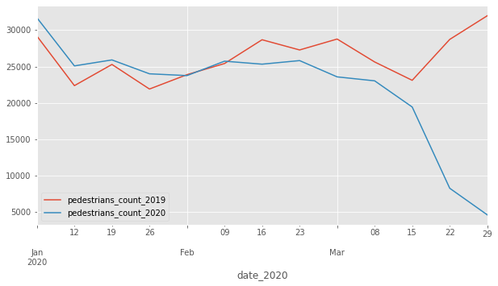

```python
# use 2020 date as index
df_viz = df.copy()
df_viz.index = pd.DatetimeIndex(df_viz['date_2020'])
df_viz = df_viz.resample('1W')[['pedestrians_count_2019', 'pedestrians_count_2020']].mean()
df_viz.plot(figsize=FIGSIZE)
```

```python
pd.DataFrame(df_viz)
```

| date_2020 | pedestrians_count_2019 | pedestrians_count_2020 |
| --- | --- | --- |
| 2020-01-05 | 29199.707317 | 31718.634146 |
| 2020-01-12 | 22369.261324 | 25084.801394 |
| 2020-01-19 | 25284.965870 | 25908.894198 |
| 2020-01-26 | 21901.331169 | 23997.029221 |
| 2020-02-02 | 23881.272727 | 23751.961039 |
| 2020-02-09 | 25414.448052 | 25735.623377 |
| 2020-02-16 | 28686.805195 | 25324.000000 |
| 2020-02-23 | 27281.259740 | 25815.535714 |
| 2020-03-01 | 28783.834416 | 23575.948052 |
| 2020-03-08 | 25627.805195 | 23029.087662 |
| 2020-03-15 | 23101.876623 | 19428.655844 |
| 2020-03-22 | 28733.639610 | 8240.123377 |
| 2020-03-29 | 31989.056818 | 4583.606061 |

## Durchschnittswoche

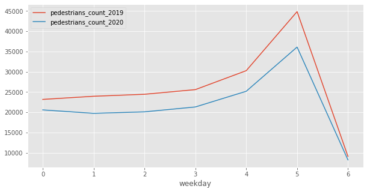

```python
df_viz = df[['pedestrians_count_2019', 'pedestrians_count_2020']].groupby(level=1).mean()
df_viz.plot(figsize=FIGSIZE)
```

## 2 te Märzhälfte

Wir vergleichen die zweite Märzhälfte (seit Montag, 16.3.2020) mit dem entsprechenden Vorjahreszeitraum

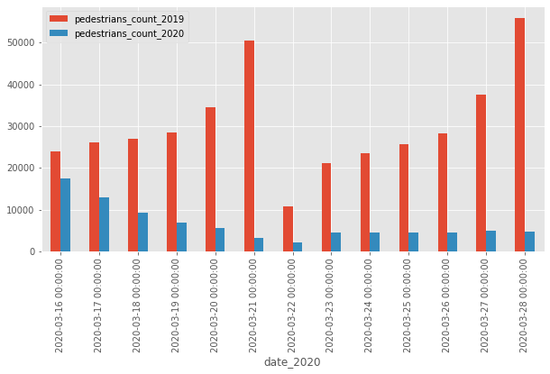

```python
df_viz = df[(df['date_2020'].dt.month == 3) & (df['date_2020'].dt.day > 15)]
df_viz.index = df_viz['date_2020']
df_viz = df_viz[['pedestrians_count_2019', 'pedestrians_count_2020']].resample('1D').mean()
df_viz.plot.bar(figsize=(10, 5))
```

```python
df_viz
df_viz['diff_perc'] = df_viz['pedestrians_count_2020'] / df_viz['pedestrians_count_2019'] * 100 - 100
df_viz
```

| date_2020 | pedestrians_count_2019 | pedestrians_count_2020 | diff_perc |
| --- | --- | --- | --- |
| 2020-03-16 | 24014.454545 | 17561.659091 | -26.870464 |
| 2020-03-17 | 26179.204545 | 12877.431818 | -50.810454 |
| 2020-03-18 | 26897.045455 | 9298.659091 | -65.428697 |
| 2020-03-19 | 28449.272727 | 6942.931818 | -75.595398 |
| 2020-03-20 | 34511.250000 | 5581.613636 | -83.826684 |
| 2020-03-21 | 50363.636364 | 3244.409091 | -93.558032 |
| 2020-03-22 | 10720.613636 | 2174.159091 | -79.719826 |
| 2020-03-23 | 21181.022727 | 4486.818182 | -78.816801 |
| 2020-03-24 | 23420.931818 | 4541.704545 | -80.608352 |
| 2020-03-25 | 25645.204545 | 4437.931818 | -82.694886 |
| 2020-03-26 | 28299.590909 | 4514.340909 | -84.048035 |
| 2020-03-27 | 37539.068182 | 4851.795455 | -87.075344 |
| 2020-03-28 | 55848.522727 | 4669.045455 | -91.639805 |

```python
hystreet.publish(df_viz, name='hystreet-2te_maerzhaelfte', overwrite=True)
```

```
'https://norddeutscherrundfunk.github.io/hystreet/hystreet-2te_maerzhaelfte.csv'
```

## Aufgeschlüsselt pro Stadt

```python
# aggregate by city
aggs = ['mean', 'median', 'sum']
df_cities = df[(df['date_2020'].dt.month == 3) & (df['date_2020'].dt.day > 15)]
df_cities = df_cities.groupby('city').agg({
    'city': 'count',
    'pedestrians_count_2019': aggs,
    'pedestrians_count_2020': aggs,
})

mean_2020 = df_cities[('pedestrians_count_2020', 'mean')]
mean_2019 = df_cities[('pedestrians_count_2019', 'mean')]

df_cities[('diff', 'abs')] = mean_2020 - mean_2019
df_cities[('diff', 'rel')] = df_cities[('diff', 'abs')] / mean_2019 * 100
df_cities = df_cities.sort_values(('diff', 'rel'))
df_cities
```

| city | city count | pedestrians_count_2019 mean | pedestrians_count_2019 median | pedestrians_count_2019 sum | pedestrians_count_2020 mean | pedestrians_count_2020 median | pedestrians_count_2020 sum | diff abs | diff rel |
| --- | --- | --- | --- | --- | --- | --- | --- | --- | --- |
| München | 26 | 48345.576923 | 30933.0 | 1256985 | 6723.807692 | 4701.5 | 174819 | -41621.769231 | -86.092197 |
| Köln | 39 | 44664.333333 | 40762.0 | 1741909 | 7456.512821 | 4980.0 | 290804 | -37207.820513 | -83.305442 |
| Hamburg | 52 | 26552.807692 | 24388.0 | 1380746 | 4689.711538 | 3918.0 | 243865 | -21863.096154 | -82.338171 |
| Freiburg | 13 | 11954.538462 | 10631.0 | 155409 | 2218.769231 | 1592.0 | 28844 | -9735.769231 | -81.439942 |
| Nürnberg | 39 | 25757.282051 | 23795.0 | 1004534 | 4885.769231 | 3534.0 | 190545 | -20871.512821 | -81.031503 |
| Stuttgart | 26 | 55196.000000 | 43125.5 | 1435096 | 10955.807692 | 8394.5 | 284851 | -44240.192308 | -80.151084 |
| Dortmund | 13 | 42969.615385 | 38649.0 | 558605 | 8922.461538 | 5767.0 | 115992 | -34047.153846 | -79.235417 |
| Düsseldorf | 52 | 30560.038462 | 27147.5 | 1589122 | 6354.442308 | 4765.5 | 330431 | -24205.596154 | -79.206694 |
| Saarbrücken | 13 | 41650.076923 | 37399.0 | 541451 | 9340.000000 | 6711.0 | 121420 | -32310.076923 | -77.575071 |
| Hannover | 39 | 43181.948718 | 33389.0 | 1684096 | 9958.871795 | 8116.0 | 388396 | -33223.076923 | -76.937419 |
| Mainz | 39 | 15861.974359 | 15049.0 | 618617 | 3660.128205 | 3085.0 | 142745 | -12201.846154 | -76.925141 |
| Münster | 26 | 23515.076923 | 21951.5 | 611392 | 5509.692308 | 4514.5 | 143252 | -18005.384615 | -76.569533 |
| Berlin | 13 | 14870.000000 | 13387.0 | 193310 | 3570.769231 | 2989.0 | 46420 | -11299.230769 | -75.986757 |
| Darmstadt | 26 | 14063.576923 | 13383.5 | 365653 | 3462.423077 | 2698.5 | 90023 | -10601.153846 | -75.380210 |
| Bonn | 39 | 29423.000000 | 28418.0 | 1147497 | 7312.102564 | 5666.0 | 285172 | -22110.897436 | -75.148345 |
| Leipzig | 26 | 33378.076923 | 29910.5 | 867830 | 8457.192308 | 5600.0 | 219887 | -24920.884615 | -74.662434 |
| Wiesbaden | 13 | 40288.153846 | 38335.0 | 523746 | 10302.000000 | 7463.0 | 133926 | -29986.153846 | -74.429208 |
| Mannheim | 13 | 20623.538462 | 18913.0 | 268106 | 5529.538462 | 4463.0 | 71884 | -15094.000000 | -73.188217 |
| Karlsruhe | 13 | 41636.230769 | 38868.0 | 541271 | 11459.230769 | 8744.0 | 148970 | -30177.000000 | -72.477742 |
| Frankfurt a.M. | 26 | 18485.923077 | 13174.0 | 480634 | 5307.653846 | 3558.0 | 137999 | -13178.269231 | -71.288132 |
| Erfurt | 13 | 16229.230769 | 15788.0 | 210980 | 5402.000000 | 3999.0 | 70226 | -10827.230769 | -66.714381 |
| Augsburg | 13 | 9083.307692 | 8300.0 | 118083 | 6735.307692 | 4801.0 | 87559 | -2348.000000 | -25.849614 |

```python
hystreet.publish(df_cities, name='hystreet-2te_maerzhaelfte_pro_stadt', overwrite=True)
```

```
'https://norddeutscherrundfunk.github.io/hystreet/hystreet-2te_maerzhaelfte_pro_stadt.csv'
```